# August 2026 Newsletter

| **AP-LS Monthly Newsletter** |
| --- |

| **Facebook \| Blue Sky \| LinkedIn** |
| --- |

| **Welcome to the August** **2026** **American Psychology-Law Society (AP-LS) Newsletter** |
| --- |

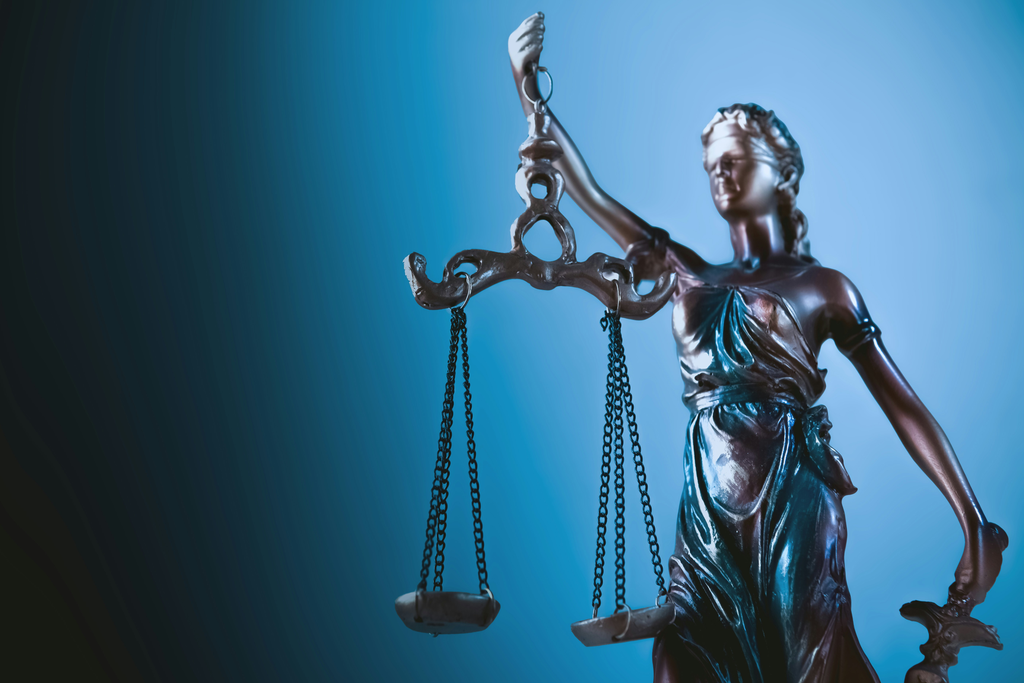

## **Presidential Column**

**Super Grateful and Immensely Enjoyed It**

By Randall T. Salekin

It has been an honor to serve as your President of the American Psychology-Law Society (AP-LS). One of my initiatives was to focus on a strength of the adolescent developmental period, namely, adolescent leadership as well as the potential for prosocial growth. These skills are important for adolescents within and outside of our legal system. Thought-provoking talks were chosen to help think about what might be done to further science on the development of strong leadership and prosocial skills for our younger generation. I hope members will continue with some of this research on leadership that may serve as a protective factor for youth at risk for involvement with the legal system. A second aim has been to facilitate the development of a strategic plan for AP-LS. This initiative was spearheaded by Chris Meissner, who started the process during his presidency. Knowing that a strategic plan would be a two-year effort, Chris asked me to help accomplish this aim across our presidencies. I have very much enjoyed and cherished being a part of this important initiative. A special strategic planning committee was formed and provided an opportunity for all of us to work closely together, get to know one another better, and to think collectively about what the upcoming goals would be for AP-LS. With membership input, I am happy to report that the plan is nearing completion and has aspirations for updating seven areas including, i) science, ii) practice, iii) advocacy and training, iv) membership development and diversity, v) recognition, vi) governance and finance, and vii) conferences and communication. This Fall, we aim to share the new AP-LS strategic plan with everyone on our AP-LS website.

I also wanted to express my gratitude to so many. I am deeply grateful to Chris Meissner, past president for all his guidance and collegiality over my presidency. I am also super grateful to Virginia Barber Rioja who has been wonderfully thoughtful in her contributions to the presidential trio. I would also like to thank our executive committee members who work tirelessly for AP-LS. I am also grateful for the outstanding work of our committee chairs and committee members. And, I am appreciative of the work on our flagship journal Law and Human Behavior and its trajectory led by our Editor, David DeMatteo. I am also grateful to Monica Miller for her leadership with our book series now with Oxford Press. Finally, our conference co-chairs for our March and August (APA) meetings deserve thanks as they have worked diligently to provide exceptionally thoughtful relevant programming for our psychology-law community. Specifically, I would like to thank Heath Hodges and Luna Filipovic Hawkins for our March 2026 conference in Reno, and Krystia Reed and Amor Correa for the August APA 2026 convention programming, in Washington, DC. I am also grateful to Tallie Armstrong and Colleen Berryessa who have already started work on our March 2027 conference, to be held in Louisville, Kentucky. Finally, a big thank you to Lane Velayo and Veronica Rand from Synergos for their organization and help with AP-LS day-to-day functioning.

As my term as president of the American Psychology-Law society comes to an end, I would also like to acknowledge the valuable contributions of those who are completing their term of service including Chris Meissner, as Past President, Lindsay Malloy, as Secretary, Jess Salerno, as Member-at-Large, Jen Groscup, as APA Council Representative, Cassidy White, as the Chair of our Student Committee, and Meg Ternes, as our Editor for the AP-LS newsletter. I would also like to acknowledge Krystia Reed as APA programming chair, who will be completing her term at the end of the APA convention this August. With regard to the society’s incoming Executive Committee Members, I extend a special welcome to President-Elect, Neil Gowensmith, Secretary, Jennifer Eno Louden, Member-at-Large, Emily Haney-Caron, APA Council Representative, Anthony Perillo, our new student Chair, and member, Sidra Capriola, and our new Newsletter Editor, Olivia Smith. I am excited to have them on board and wish them much success in the coming year.

As always, I hope everyone continues to visit our **website** for resources and information on the society itself, awards, training opportunities, grants, upcoming elections, and related opportunities. I hope you will continue to use these resources and opportunities to stay connected with AP-LS.

I have been surprised at how quickly my time as AP-LS president has gone, yet also just how much that I have learned and benefitted from working with the executive committee and having a chance to interact even more closely with AP-LS members. I am grateful for the opportunity!

I look forward to staying in touch with everyone in the upcoming year.

*Randy Salekin can be reached at the Department of Psychology, University of [Alabama. 330 Kirkbride Lane, Tuscaloosa AL 35487](https://www.google.com/maps/search/Alabama.+330+Kirkbride+Lane,+Tuscaloosa+AL+35487?entry=gmail&source=g).*  
*E-mail: **rsalekin@ua.edu***

## **American Psychology-Law Society Policy Statement on Immigration Detention**

The American Psychology-Law Society (AP-LS) has significant concerns regarding the expansion of immigration detention in the United States, including rising numbers of detained children. A substantial body of research demonstrates that immigration detention is associated with significant and often lasting mental health harm, including depression, anxiety, and posttraumatic stress. Furthermore, recent reports and investigations document systemic deficiencies in care, the overuse of segregation, credible allegations of abuse and neglect, and an increasing number of deaths in Immigration and Customs Enforcement (ICE) detention. In light of this evidence, AP-LS calls for reducing reliance on detention, prioritizing community-based alternatives, improving access to mental health care, strengthening oversight and accountability, and implementing reforms to reduce prolonged detention. These recommendations are grounded in psychological science and align with AP-LS’s commitment to enhancing well-being, justice, and human rights.

To read the entire APA Division 41 statement, click **here**.

## **AP-LS 2027 Distinguished Service Award**

The AP-LS Distinguished Service Award recognizes members that have contributed exceptional meritorious professional service to the Society and/or the field of legal/forensic psychology. Examples might include (but are not limited to): extensive committee service and leadership for the Society, community outreach/advocacy, services provided to state, local, or federal governments, or uncompensated consultation in legal or clinical services. Nominees must be members of AP-LS, have been in the field for at least 10 years since their doctoral degree, and have demonstrated a sustained track record of leadership and service. Up to two individuals may be recognized each year.  
Recipients will be formally recognized at the AP-LS Annual Conference. Awardees will receive a plaque, complimentary registration to that year’s conference, and up to $1,000 in travel reimbursement upon request.  
All nominations should be submitted to: **https://tinyurl.com/APLS-Awards-2026** by **November 15, 2026**. Self-nominations will not be considered. The nomination packet should be a single PDF document that includes:

● A copy of the nominee’s CV;  
● A letter detailing the nominee’s distinguished contributions to psychology and law; and  
● Any additional letters of support that address the nominee’s service to the field.  
More information about the award can be found at: **https://ap-ls.org/awards/awards/distinguishedservice**.

## **AP-LS 2027 Distinguished Contributions to Psychology and Law Award**

The AP-LS Award for Distinguished Contributions to Psychology and Law honors one who has made distinguished theoretical, empirical, and/or applied contributions to the field of psychology and law. This award will not be presented on a regular basis. Rather, it will be reserved for those individuals whose contributions are so unusual as to merit special commendation. This award is not exclusively for AP-LS members, and anyone who meets these criteria may be nominated (but self-nominations are not considered).

Recipients will be formally recognized at the AP-LS Annual Conference. Awardees will receive a plaque, complimentary registration to that year’s conference, and up to $1,000 in travel reimbursement upon request.  
All nominations should be submitted to: **https://tinyurl.com/APLS-Awards-2026** by **November 15, 2026**. Self-nominations will not be considered. The nomination packet should be a single PDF document that includes:

● A copy of the nominee’s CV;  
● A letter detailing the nominee’s distinguished contributions to psychology and law; and  
● Names and addresses of four individuals who are familiar with the nominee’s work and who would be able to address the nominee’s contributions to the field of psychology and law (or additional letters from these four individuals).

More information about the award can be found at: **https://ap-ls.org/awards/awards/distinguished**.

## **AP-LS 2027 Mid-Career Award**

The AP-LS Mid-Career Award recognizes members whose work has already substantially contributed to the fields of forensic and legal psychology. Up to three awards may be given each year to recognize scholars who have contributed through research, theory, and/or practice within these fields (e.g., experimental, forensic, corrections, etc.).  
Nominees will have completed their terminal degree 10 - 25 years before the nomination deadline. The nominee should be a member of AP-LS.  
Recipients will be formally recognized at the AP-LS Annual Conference. Awardees will receive a plaque, complimentary registration to that year’s conference, and up to $1,000 in travel reimbursement upon request.  
All nominations should be submitted to: **https://tinyurl.com/APLS-Awards-2026** by **November 15, 2026**. Self-nominations will not be considered. The nomination packet should be a single PDF document that includes:  
● A copy of the nominee’s CV;  
● A letter detailing the nominee’s distinguished contributions to psychology and law; and  
● Any additional letters of support that address the nominee’s contributions to the field.  
More information about the award can be found at: **https://ap-ls.org/awards/awards/midcareer**.

## **AAFP/AP-LS 2027 Saleen Shah Award**

The Saleem Shah Award is an annual award co-sponsored by the American Academy of Forensic Psychology and the American Psychology-Law Society recognizing early career excellence and contributions to the field of psychology and law. Please see **https://aafpforensic.org/awards/saleem-shah-award-for-early-career-excellence-in-psychology-and-law/** for more information.  
AAFP and AP-LS leadership have expanded the recognition of emerging talent in our field by honoring up to two (2) early career forensic or legal psychologists annually for this prestigious award. This modification aims to provide greater opportunities for acknowledging outstanding contributions from professionals in the early stages of their careers.  
The focus of a nominee's contributions may be in any area of forensic/legal psychology practice, research, or public policy. The selection committee will prioritize one winner from more applied clinical domains and one winner from field or experimental research that can include less clinical domains. Of course, we recognize that excellent work (like Saleem Shah’s) may span these broad categories or be difficult to categorize.  
The recipient(s) must have received a doctoral degree (or law degree, whichever comes later, if both have been earned) within the last 10 years (as defined by APA, year 2015 or later, inclusive of 2015). The award includes $2,000, as well as the opportunity to give the Saleem Shah Address at the next meeting of the American Psychology-Law Society.  
All nominations should be submitted to: **https://tinyurl.com/APLS-Awards-2026** by November 15, 2026. Self-nominations will not be considered. The nomination packet should be a single PDF document that includes:  
● a letter detailing the nominee’s contributions to psychology and law, and  
● a copy of the nominee’s vita.

More information about the award can be found at: **https://ap-ls.org/awards/awards/saleemshah**.

## **Consider Joining the Spanish-Speaking Forensic Psychology Network**

[figure not shown]

## *Law and Human Behavior* Editorial Fellowship

The Editorial Team of *Law and Human Behavior* is seeking nominations for one editorial fellowship position for an early-career psychologist (ECP) from a group historically underrepresented in the academy and/or professional practice. The fellow will serve a 12-month term beginning January 1, 2027, and the position includes an honoraria stipend of $2,500 USD.

*Law and Human Behavior’s* Editorial Fellowship Program seeks to elevate leadership opportunities for ECPs from communities that have been historically underrepresented in research and publishing leadership roles. Such individuals include, but are not limited to, psychologists who are Black, Indigenous, or other people of color and ethnicities as well as those psychologists who study, advocate on behalf of, or practice primarily with communities of color. Members of other underrepresented communities (e.g., LGBTQIA+ individuals, individuals with disabilities) or who work with or advocate on behalf of individuals from these communities will be considered.

**Qualifications**  
The fellowship is open to qualified candidates who meet the above description and are no more than 10 years postdoctoral. Preference will be given to applicants who have experience conducting peer reviews and who are interested in pursuing a leadership role with a peer-reviewed journal.

**Responsibilities**  
The fellow will work closely with the *Law and Human Behavior* Editorial Team (Editor-in-Chief and Associate Editors) to develop their editorial leadership skills. The fellow will be mentored to perform the tasks typically required of an Associate Editor, including screening manuscripts for appropriateness, inviting reviewers to review manuscripts, and writing decision letters. The fellow will also participate in periodic meetings (via Zoom) with the *Law and Human Behavior* Editorial Team. Fellows will be credited on the journal masthead and, upon successful completion of the fellowship, will become members of *Law and Human Behavior*’s Editorial Board.

**How to Apply**  
Interested candidates should send their application to the Editor-in-Chief of *Law and Human Behavior*, David DeMatteo (**david.dematteo@drexel.edu**), by **November 1, 2026**. Applicants should provide a CV and a letter of interest that (a) describes their expertise and experience, (b) provides context for their interest in the editorial fellowship program, and (c) indicates how their participation in the editorial fellowship program will contribute to the journal’s advancement.

## **American Psychology-Law Society Book Award**

The American Psychology-Law Society Book Award Committee invites nominations for the 2027 Lawrence S. Wrightsman Book Award, which recognizes outstanding scholarship in psychology and law. The award alternates annually between edited and authored books. This year we are accepting nominations for authored books published in 2024 and 2025. The deadline for nominations is **November 1, 2026**. We kindly request an electronic copy and a physical copy of the book to be submitted. Nominations (including self-nominations) and e-versions of the book should be sent to the Chair of the Committee:

Catherine Burke, Psy.D **catherine.burke@yale.edu**.

## **Invitation to Contribute to SAGE Encyclopedia of Bullying**

Dr. Lisa Rosen & Dr. Stephanie Fredrick are inviting contributors for the SAGE Encyclopedia of Bullying. This 2-volume encyclopedia is designed to provide students from diverse disciplines with a comprehensive understanding of bullying across the lifespan and across different contexts. Entries in the SAGE Encyclopedia of Bullying are intentionally concise and manageable, making the contribution process both efficient and impactful. **Several entries focused on legislation/legal issues remain available**, and both the due date and word count are flexible. If you are interested in authoring an entry, please contact **lrosen@twu.edu** or **ssfredri@buffalo.edu**. We look forward to hearing from you!

## **Call for Papers -** **Journal of Child & Adolescent Trauma Special Issue on** **Identifying and Uncoupling the Links Between Trauma and Juvenile Justice**

[figure not shown]

The Journal of Child and Adolescent Trauma (JCAT; 5-year IF: 2.3) invites manuscripts for a special issue entitled *“Identifying and Uncoupling the Links Between Trauma and Juvenile Justice”* planned for publication in the summer of 2027.

Although the high prevalence of trauma exposure and posttraumatic stress symptoms amongst youth in the juvenile justice system is well-established, still needed is research directed toward identifying the underlying developmental processes that account for those links. Also important are attempts at prevention and intervention that are devoted to uncoupling the links by investigating sources of resilience or providing trauma-informed treatments and programming within youth-serving organizations. For this special issue, most welcome will be submissions that focus on youth involved in the justice system, although studies involving other carceral settings to which youth in trouble with the law are diverted (e.g., “bootcamps,” wilderness programs, residential facilities, etc.) might also be considered as long as justice involvement is established. Longitudinal and retrospective studies of adults who experienced justice involvement in their youth also will be considered if the study questions are informed by a developmental perspective.

JCAT welcomes basic research and intervention studies that employ quantitative, qualitative, or mixed methods, as well as work that includes diverse samples and derives from diverse cultural contexts. In keeping with best practices in research, cross-sectional studies testing suppositions derived from developmental models should be framed cautiously as tests of indirect effects rather than “mediation” (see O’Leary et al., 2018; Maxwell & Cole, 2007; Weems, 2025). Systematic reviews and meta-analyses will be welcome, following best practice guidelines (e.g., Siddaway et al., 2019). High-quality conceptual papers that promise to move the field forward also will be considered.

Manuscripts must be submitted no later than October 1, 2026 to be included in the special issue. The journal website provides details about the submission process (**https://link.springer.com/journal/40653/submission-guidelines**) including the need to follow APA 7th ed. manuscript preparation guidelines in all respects. Please note that all submitted manuscripts will be subject to a robust double-blind peer review process and final acceptance is not guaranteed. Article-processing fees will apply only if authors opt for their paper to be published open access. Accepted papers will be published online promptly after acceptance.

For inquiries, please contact Dr. Patricia K. Kerig, Editor in Chief: **p.kerig@utah.edu**

Call for Book Proposals

The American Psychology-Law Society invites proposals for new titles in its book series, which is now published by Oxford University Press. We publish authored and edited volumes on current issues at the intersection of psychology and law. Books are typically a state of the science synthesis of a body of existing research with implications for practice and/or policy. Authors and editors should have a substantial and recent track record of publication and/or practice in psychology or law, and at least one should hold a doctorate in psychology or closely related behavioral science. If you have a proposal for a new book in the series or you would simply like more information, please reach out to a member of the editorial team. We would be happy to discuss possible topics and fit for the series. Inquiries are accepted on a continuous basis—submit anytime!

The editorial board members are:

- Monica Miller, Division 41 Book Series Editor (mkmiller@unr.edu)
- Monique Bowen, Division 41 Book Series Associate Editor (mbowen2@antioch.edu)
- Dan Murrie, Division 41 Book Series Associate Editor (dcm3w@uvahealth.org)
- Lora Levett, Division 41 Book Series Associate Editor (llevett@ufl.edu)

Request for Proposals for Chapters and Essays

Monica K. Miller, David DeMatteo, and Daniel Krauss are editors of the book series “Advances in Psychology and Law,” which seeks to enhance understanding of the connections between these disciplines, present “state of the science” summaries for current researchers, and provide a starting point for scholars wanting to delve into a new topic of study by reading an up-to-date review chapter or brief essay on that topic. All areas of psychology (e.g., developmental, social, cognitive, clinical, neuroscience) and law (e.g., criminal, civil, contracts, property, family) are appropriate for inclusion. Student authors are welcome under the supervision of a PhD co-author.

Chapters and essays will be primarily reviews or meta-analyses. Although they might provide some data to illustrate a new phenomenon, they are not meant to be data-driven like a journal article. Review chapters and essays will be on particular topics relevant to psychology and law and will be of current interest to the field. Chapters (and especially essays) will typically summarize research on one particular topic, rather than focusing on the entire body of research in an area (e.g., focusing on the Weapon Focus effect rather than the entire body of eyewitness memory). Chapters will be relatively long (30-40 pages d.s.), which will allow authors to provide in depth analysis and take calculated risks (e.g., engaging in informed speculation about future research or the consequences of particular legal policies).

Essays will be shorter (approximately 10-14 pages d.s.) because they discuss a topic that is new and/or has less previous research to synthesize.

The book series has an editorial board of distinguished scholars who are experts in various areas in psychology and law. The editors strive to produce one volume in the series approximately every 12-18 months.

Overviews of the previous volumes can be viewed here to ensure topics have not been recently included in the series and to see examples of chapters: http://www.springer.com/series/11918?detailsPage=titles

Submit an approximately 300 word description and title and indicate if you want to write an essay or chapter. Specify both the legal component and the psychological component of your topic. Please include a sampling of key references and a CV of authors. Inquiries are accepted on a continuous basis—submit anytime! Email submissions to Monica Miller at mkmiller@unr.edu.

**Executive Committee**

| For more information or if you wish to contact a member of the AP-LS Executive Committee, details can be found **HERE**. |
| --- |

## **On The Job or Postdoc Market? AP-LS Job Postings**

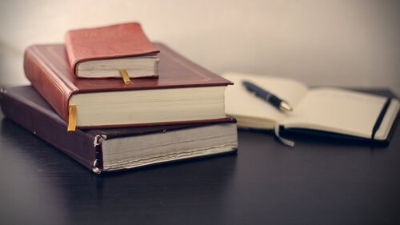

| Check out **AP-LS's Job Postings Page** for up-to-date information on available psychology-law positions. |
| --- |

| View Job Postings |
| --- |

## **Newsletter Editorial Board**

| EDITOR Olivia Smith osmith3@uwyo.edu ASSOCIATE EDITOR Taylor Petty tepetty@usi.edu CONTENT EDITORS–RESEARCH BRIEFS Kelly McWilliams kmcwilliams@jjay.cuny.edu Veronica Johnson vjohnson@jjay.cuny.edu |
| --- |

[output not shown]

## **Membership Services**

[output not shown]

## **Newsletter Archives**

| **Archives of the newsletter are available at https://ap-ls.org/newsletter.** |
| --- |

| **American Psychology-Law Society** www.ap-ls.org \| (704) 456-7276 \| office@ap-ls.org |
| --- |

| *Copyright © American Psychology-Law Society* *Division 41 of the American Psychological Association All rights reserved.* |
| --- |